# Problem set 3: Food stamp program participation

Marjorie Blanco

10/22/2018

# Question 1

# Question 2

Do descriptive statistics on the state unemployment rate (unempr). This tells you that the average percent unemployment in the data is approximately:

```r
summary(snap$unempr)
```

```
##    Min. 1st Qu.  Median    Mean 3rd Qu.    Max.
## 0.02258 0.04167 0.05050 0.05145 0.06044 0.11292
```

```r
mean(snap$unempr)
```

```
## [1] 0.05145327
```

# Question 3

Your descriptive statistics on the state food stamp program participation rate (fsp.rate) tells you that the average percent of the population that are on food stamps equals approximately

```r
summary(snap$fsp.rate)
```

```
##    Min. 1st Qu.  Median    Mean 3rd Qu.    Max.
## 0.01788 0.05998 0.07463 0.08254 0.10013 0.21675
```

```r
mean(snap$fsp.rate)
```

```
## [1] 0.08254047
```

# Question 4

What is the maximum percent of a state’s population that was on food stamps in the data?

```r
snap$fsp.rate1 <- snap$i.fsp.tot / snap$pop
summary(snap$fsp.rate)
```

```
##    Min. 1st Qu.  Median    Mean 3rd Qu.    Max.
## 0.01788 0.05998 0.07463 0.08254 0.10013 0.21675
```

```r
max(snap$fsp.rate)
```

```
## [1] 0.2167525
```

# Question 5

You run a regression with food stamp program participation (“fsp.rate”) as the dependent variable (Y) and unemployment (“unempr”) as the explanatory variable (X).

Which of the values below best matches your b_1 (slope parameter) result?

```r
fit <- lm(fsp.rate~unempr, data = snap)
summary(fit)
```

```
##
## Call:
## lm(formula = fsp.rate ~ unempr, data = snap)
##
## Residuals:
##       Min        1Q    Median        3Q       Max
## -0.081846 -0.018130 -0.002817  0.016029  0.114945
##
## Coefficients:
##             Estimate Std. Error t value Pr(>|t|)
## (Intercept) 0.018082   0.003083   5.864 6.09e-09 ***
## unempr      1.252759   0.057738  21.697  < 2e-16 ***
## ---
## Signif. codes:  0 '***' 0.001 '**' 0.01 '*' 0.05 '.' 0.1 ' ' 1
##
## Residual standard error: 0.02637 on 1018 degrees of freedom
## Multiple R-squared:  0.3162, Adjusted R-squared:  0.3155
## F-statistic: 470.8 on 1 and 1018 DF,  p-value: < 2.2e-16
```

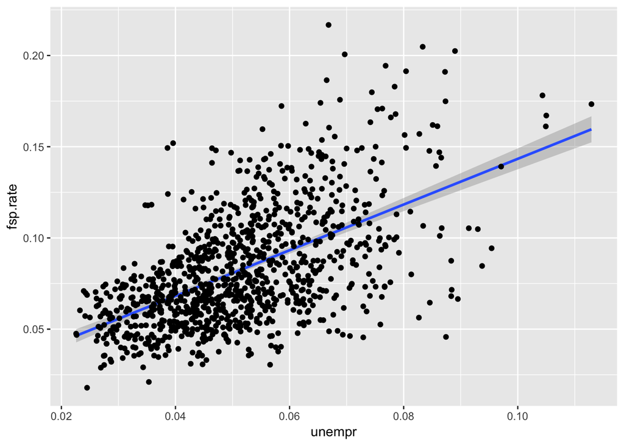

```r
p <- ggplot(snap , aes(x = unempr, y = fsp.rate)) +
  geom_smooth(method = "lm") +
  geom_point()
p
```

# Question 6

The estimated coefficient for the explanatory variable in the regression model you just ran tells us that for every `1 percentage point` increase in unemployment, we expect the participation in the food stamp program to `increase` by `1.25` `percentage points`.

```r
fsp.rate1 <- 1.252759  * 0.08 + 0.018082
fsp.rate1
```

```
## [1] 0.1183027
```

```r
fsp.rate2 <- 1.252759  * 0.081 + 0.018082
fsp.rate2
```

```
## [1] 0.1195555
```

```r
fsp.rate2 - fsp.rate1
```

```
## [1] 0.001252759
```

```r
fsp.rate3 <- 1.252759  * 0.09 + 0.018082
fsp.rate3
```

```
## [1] 0.1308303
```

```r
fsp.rate3 - fsp.rate1
```

```
## [1] 0.01252759
```

# Question 7

Say that our null hypothesis is that the effect of unemployment on food stamp participation is equal to zero and that the alternative hypothesis is that it is not equal to zero. Using a significance level of 5% we `can` reject the null hypothesis because the `Pr(>|t|)` is `less than` `0.05`.

# Question 8

We want to know what the predicted percent participation in the food stamp program for a state with 8% unemployment. Using your regression results which of the numbers below do you think is the predicted percent participation. You *can* use R but it is probably faster to just calculate the number using your calculator. If you are using R, this is how you call a coefficient:

coef(modelName)[“coefficientName”]

The coefficientName is exactly as it is written in the summary.

```r
fsp.rate <- 1.252759  * 0.08 + 0.018082
round(fsp.rate*100, 2)
```

```
## [1] 11.83
```

```r
fsp.rate <- 1.252759  * 0.081 + 0.018082
round(fsp.rate*100, 2)
```

```
## [1] 11.96
```

```r
new.df <- data.frame(unempr = c(0.08))
round(predict(fit, new.df), 4)
```

```
##      1
## 0.1183
```

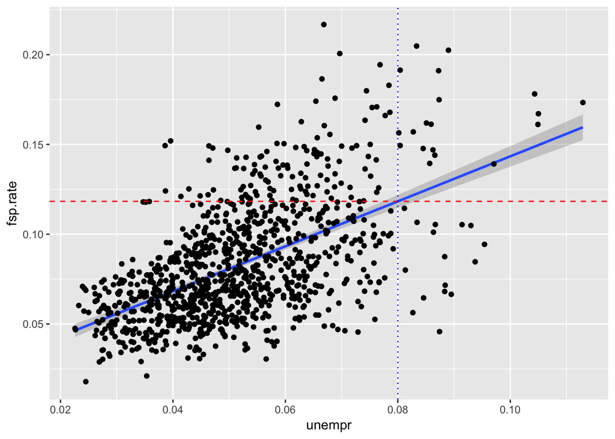

```r
p +
  geom_hline(yintercept=predict(fit, new.df), linetype="dashed",
                color = "red", size=0.5) +
  geom_vline(xintercept = new.df[1,], linetype="dotted",
                color = "blue", size=0.5)
```

# Question 9